# STSCI 5065 - Lecture 19

HDFS Data Visualization

Harry Lu

# 1 Statistical Data Visualization With Seaborn

- Seaborn is a Python visualization library based on `matplotlib`. You can easily use data in HDFS or other file systems to draw attractive and informative statistical graphics. It offers:
  - Tools for choosing color palettes to make beautiful plots, and fitting and visualizing linear regression models for different kinds of independent and dependent variables.
  - Functions for visualizing univariate and bivariate distributions, comparing them between subsets of data, visualizing matrices of data, using clustering algorithms to discover structure in those matrices, and plotting statistical time series data with flexible estimation and representation of uncertainty around the estimate.
  - High-level abstractions for structuring grids of plots to build complex visualizations.

# 2 `seaborn.pairplot()`

- The `pairplot()` function plots pairwise relationships in a dataset. It creates a grid of Axes such that each variable in data will be shared in the y-axis across a single row and in the x-axis across a single column. The diagonal Axes are treated differently, drawing a plot to show the univariate distribution of the data for the variable in that column.

# 3 The Pairplot of the Iris Dataset

## 3.1 Basic

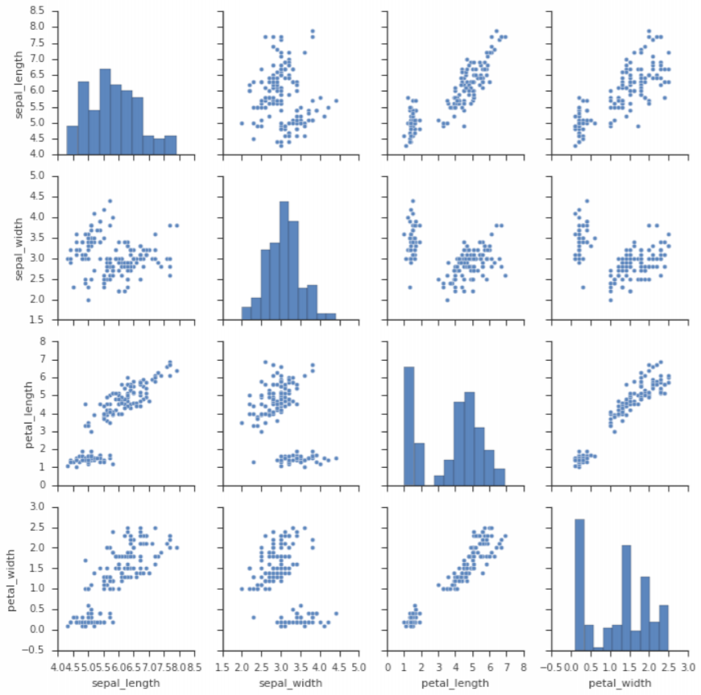

```python
%pylab inline
import seaborn as sns
sns.set(style = "ticks", color_codes = True)
iris = sns.load_dataset("iris")
g = sns.pairplot(iris)
```

## 3.2 Enhanced 1

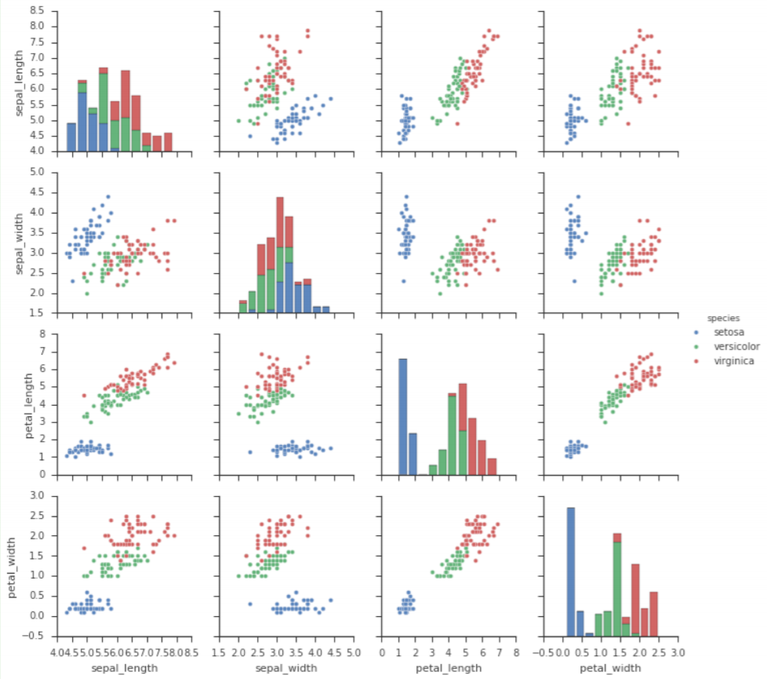

```python
g = sns.pairplot(iris, hue = "species")
```

## 3.3 Enhanced 2

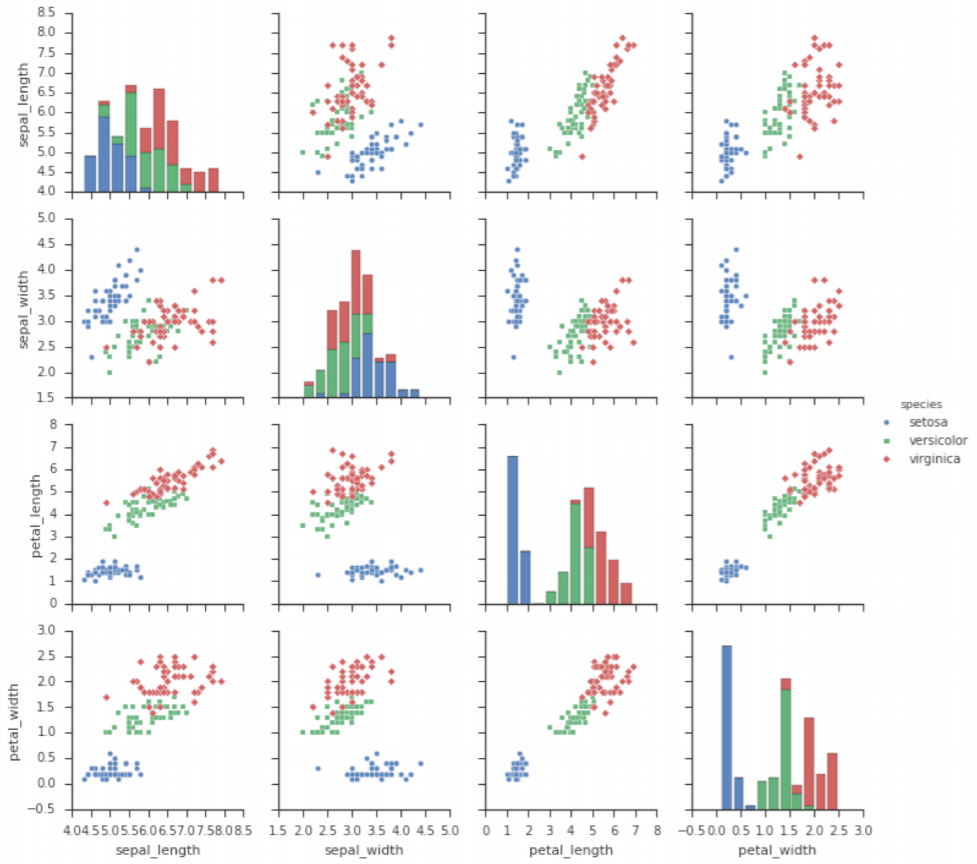

```python
g = sns.pairplot(iris, hue = "species", markers = ["o", "s", "D"])
```

## 3.4 Enhanced 3

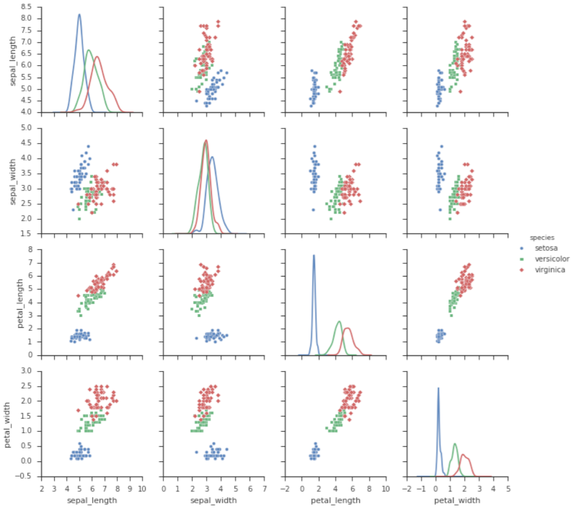

```python
g = sns.pairplot(iris, hue = "species", markers = ["o", "s", "D"], diag_kind = "kde")
```

# 4 The Swarmplot of the Tips Dataset

## 4.1 Basic

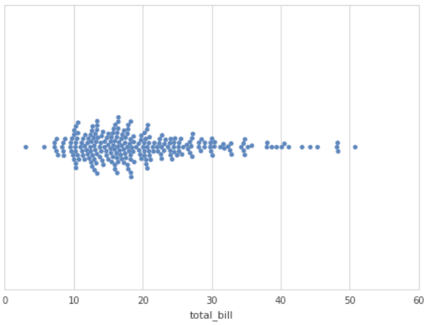

```python
import seaborn as sns
sns.set_style("whitegrid")
tips = sns.load_dataset("tips")
ax = sns.swarmplot(x = tips["total_bill"])
```

## 4.2 Enhanced

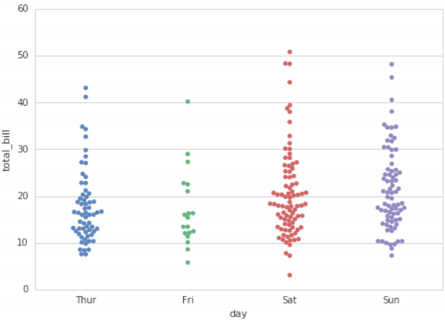

```python
ax = sns.swarmplot(x = "day", y = "total_bill", data = tips)
```